# Markdown Figure Practice

Diandra Rivera

Purpose of Document

This pretend homework assignment needs remediation. Using what you learned in the Markdown Tutorial, remediate this document to [AA conformance](https://websiteaccessibilitychecker.com/checker/index.php) to confirm your understanding.

# Problem 1

*Vibing*, in mathematics, means *giving and receiving those steady-state vibes*.

Six friends start *vibing* according to the diagram below. Friends 1, 2, 3, and 4 are chill, but κ and Γ are vibe thieves who slowly drain the vibes from the group. What is the smallest vibe rate ρ that Γ must have to hog more vibes than κ *after a very long time*. Said differently, find

$$\underset{\rho (t) }{\operatorname{min}} \left [ \left \{ \underset{t
\to \infty}{\rho (t)} \ \colon \operatorname{\text{vibe}}(\Gamma) >
\operatorname{\text{vibe}}(\kappa) \right \} \right ]
\qquad{(1)}$$

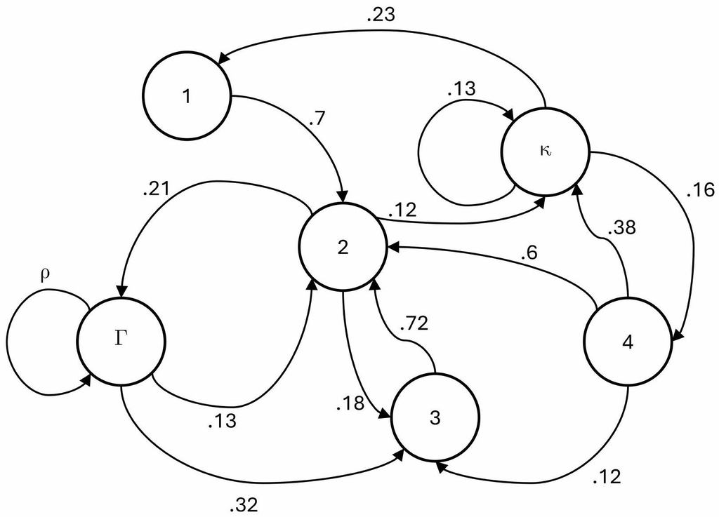

Figure 1: A directed graph structure with node set $\{1,2,3,4,\kappa,\Gamma \}$, and directed arrows describing the relationship between them. See footnote below for more details[^1].

# Problem 2

Linguistics can tell us whether it is *most correct* to say

> “I butter up your toast.”

or

> “I butter your toast up.”[^2]

Find the transformation that maps the syntax tree of the former to the latter, and prove that it has no inverse. Finally, *what does this say about which is most correct?*

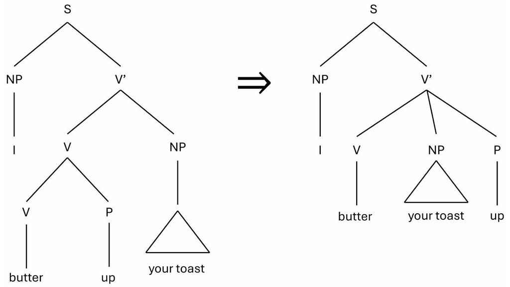

Figure 2: A mapping (represented by an arrow) transforms “I butter up your toast.” to “I butter your toast up.” See footnote for description of tree structures[^3].

# Problem 3

Every carpenter knows that if you have a 2x2 grid of tiles and one of the tiles is missing, the remaining tiles will be shaped like an L.

But carpentry can be lonely, and there is a lot of time to think. A carpenter might wonder if it’s possible to construct an arbitrarily large $2^{n+1} \ n \in \mathbb{N}$ square grid with such L shaped tiles if a single tile is missing anywhere on the grid.

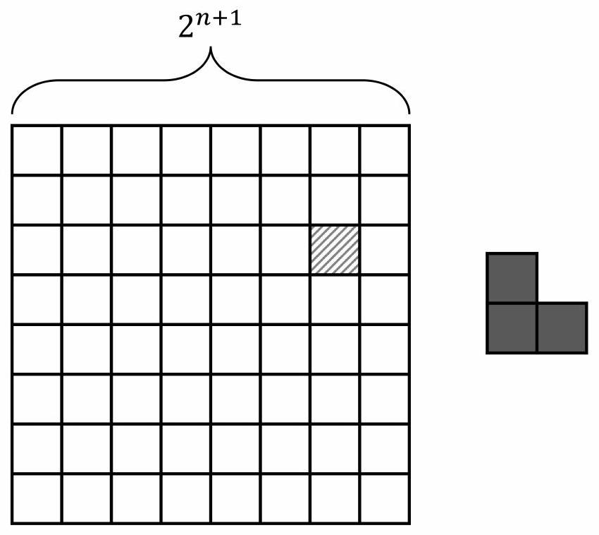

Figure 3: A 2<sup>n+1</sup> square tile grid with one missing tile (shaded). L shaped sets of 3 tiles are proposed to be able to cover the entire square.

The carpenter might start by partitioning the entire grid into equally sized sub-grids, and place an L-shaped tile in the middle of the entire grid to create “missing tiles” in the three sub-grids which don’t already have a missing tile. With the example below, the carpenter needs to perform two such partitions to understand how to think about tiles[^4].

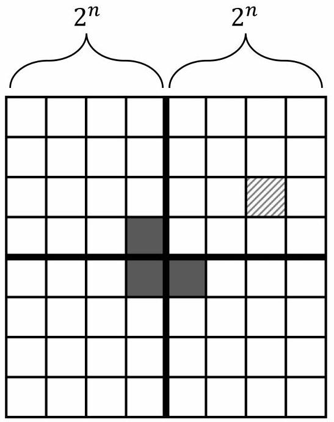

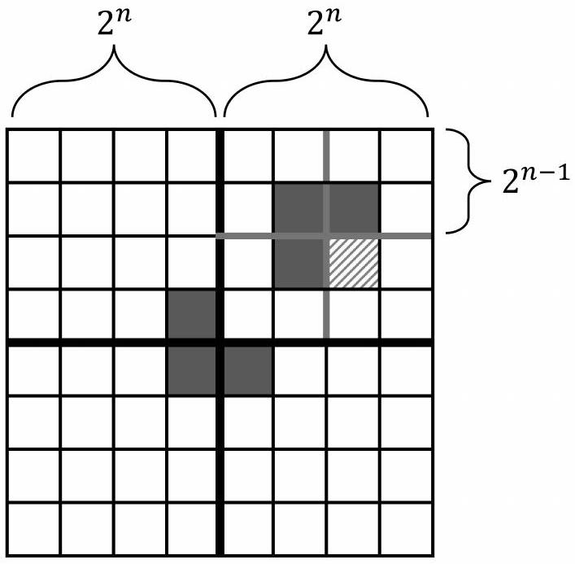

Figure 4: Principle of L-tile covering. a — The 2<sup>n+1</sup> grid is sequentially partitioned into four 2<sup>n</sup> sub-grids. Appropriate placement of an L-shaped tile in its center ensure one “mssing” tile in each quadrant., b — The principle of appropriate L-shaped tile placement can be further applied to sub-sub grids. Partitioning a quadrant into four 2<sup>n-1</sup> sub-sub-grids shows a possible L-tile covering. See footnote for more details[^5].

1. How many L-shaped tiles are required to cover the grid on the right hand side of the above figure?
2. If the carpenter needed to perform 5 partitions to make suitable sub-grids, how big does **n** need to be?
3. Prove that any such grid can be covered in L shaped tiles.

# Problem 4

> **Potato Theorem**: For $n \in \mathbb{N}$ sets, it is impossible to draw a proper Venn diagram without at least one set from the potato group $\mathbb{P}$.

Recall that a proper Venn diagram must have a total of 2<sup>n</sup> intersecting sets. We demonstrate the essence of the proof below:

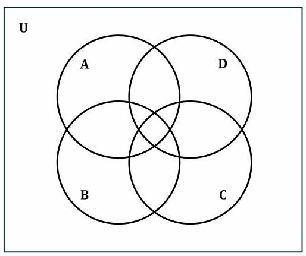

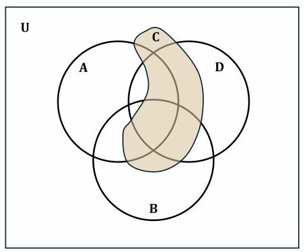

Figure 5: Overlapping sets A,B,C,D. a — Equidistant equivalently sized sets do not form a venn diagram because some sets don’t exist, b — In B, the potato theorem is applied to set C to form a proper Venn diagram. See footnote for description of drawn sets and of the application of the potato theorem[^6]

1. Verify that the set of overlapping circles does not contain the set $(A \cap C) \backslash (B \cup D)$.
2. Use the figure on the right to develop a proof by induction of the **Potato Theorem**.

# Problem 5

> **Bugle’s Lemma**: The smallest cone $\mathbb{C}$ normal to the Pringle $\mathbb{S}$ containing tangent potato $P$ has a tapering angle equal to the kurtosis in starch distribution about $P$’s principle axis $\mu$ and $||\mu \times \vec{n}||$. We call this cone a Bugle (*named after the rather unpopular snack*).

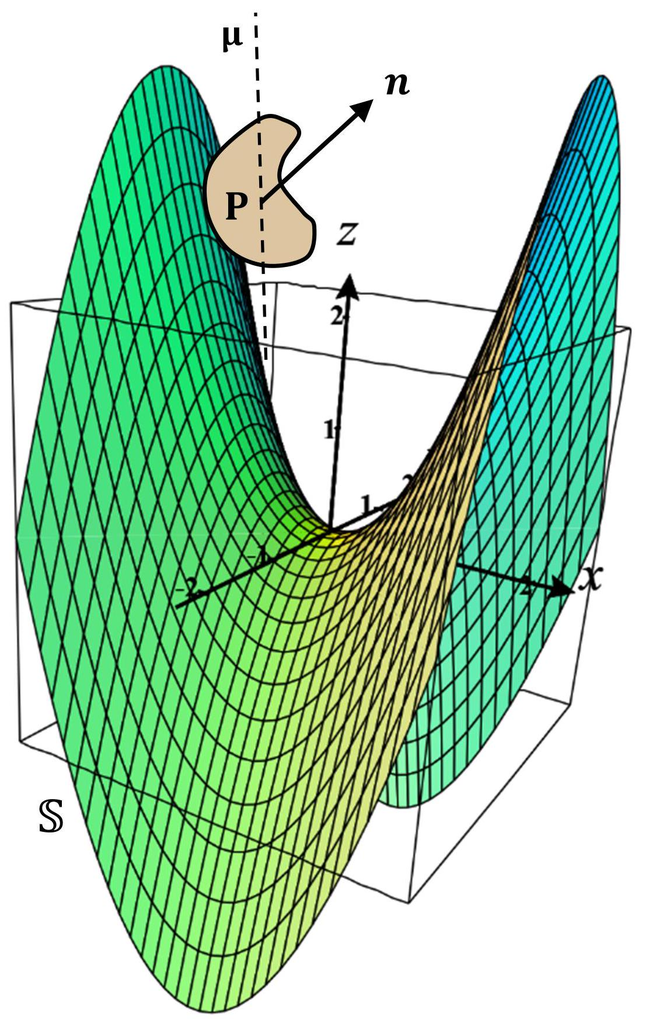

A potato is tangent to a hyperbolic paraboloid in $[x,y,z]$-space with surface normal and principle axis identified. Please see footnote for more details[^7].

1. Find the critical pringle points $\mathbb{S}_c$ where $\mathbb{S}$ and the Bugle are locally tangent. Describe your answer in terms of a free vector $\vec{u}$, the principle axis of $P$ expressed in the $x,y,z$ frame.
2. Is the Bugle a characteristic? Why or why not? Justify your answer.
[^1]: Problem 1 directed graph of vibe relations needed to solve eq. 1.

    The following table describes the relationship between nodes $\{1,2,3,4,\kappa,\Gamma \}$ and the unitless magnitude of the vibing between them.

    Problem 1: tabulation of directed vibing among friends

    | Node | Directed Towards | Magnitude |
    | --- | --- | --- |
    | 1 | 2 | 0.7 |
    | 2 | 3 | 0.18 |
    | 2 | κ | 0.12 |
    | 2 | Γ | 0.21 |
    | 3 | 2 | 0.72 |
    | 4 | 2 | 0.6 |
    | 4 | 3 | 0.12 |
    | 4 | κ | 0.38 |
    | κ | 1 | 0.23 |
    | κ | 4 | 0.16 |
    | κ | κ | 0.13 |
    | Γ | 2 | 0.13 |
    | Γ | 3 | 0.32 |
    | Γ | Γ | ρ |

[^2]: Inspired by McCawley, J.D. “Parentheticals and Discontinuous Constituent Structure,” *Linguistic Inquiry* vol 13(1) 1982, pp.91-106. URL: [http://www.jstor.org/stable/4178261?origin=JSTOR-pdf]
[^3]: Problem 2 tree structures. The lists describes the hierarchical relationship in each tree graph.

    “I butter up your toast.”
    1. S
       1. NP
          1. I
       2. V’
          1. V
             1. V
                1. butter
             2. P
                1. up
          2. NP
             1. your toast

    “I butter your toast up.”
    2. S
       1. NP
          1. I
       2. V’
          1. V
             1. butter
          2. NP
             1. your toast
          3. P
             1. up
[^4]: Inspired by example 6.2.4 of Daniel J. Velleman’s textbook “How To Prove It” [available from the publisher](https://www.cambridge.org/highereducation/books/how-to-prove-it/6D2965D625C6836CD4A785A2C843B3DA#overview).
[^5]: Problem 3 partitioning tiles. This figure outlines the partitioning and subsequent L-tile placement in order to begin the proof. Two iterations of the same 2<sup>n+1</sup> square are shown, arranged left to right in order of the partitioning sequence.

    Left:
    - The 2<sup>n+1</sup> grid is partitioned into four 2<sup>n</sup> sub-grids.
    - A missing tile is near the center of the upper right 2<sup>n</sup> sub-grid.
    - A single L-shaped tile is placed in the center of the 2<sup>n+1</sup> grid.
      - This placement is such that 1 of its 3 tiles is in the other three 2<sup>n</sup> sub-grids.

    Right:
    - The top right 2<sup>n</sup> sub-grid is partitioned further into four 2<sup>n-1</sup> sub-sub-grids.
    - In this example, each of the 2<sup>n-1</sup> sub-sub-grids has four tiles.
    - One of the four 2<sup>n-1</sup> sub-sub-grids has a single tile missing.
    - A single L-shaped tiling is placed such that 1 of its 3 tiles is in all the other 2<sup>n-1</sup> sub-sub-grids.
    - Now, each of the 2<sup>n-1</sup> sub-sub-grids contains exactly 3 free tiles arranged in an L-shape.
    - Placement of an L-shaped tile into each of these sub-sub-grids covers the entirety of the larger 2<sup>n</sup> sub-grid.
      - Performing the same procedure in the other 3 2<sup>n</sup> sub-grids will provide full coverage of the entire 2<sup>n+1</sup> grid.
[^6]: Problem 4 overlapping sets. This footnote describes how the potato-set C is arranged with respect to the circular sets A,B,D in the Venn diagram.
    - The set C is located just above A ∩ D.
    - follows the circumference of A as it intersects other sets, and is split into left and right halves by this circumference where overlap occurs.

    From top to bottom:
    1. Left half of C
       1. C ∩ A
       2. C ∩ A ∩ D
       3. C ∩ A ∩ D ∩ B
       4. C ∩ A ∩ B
    2. Right half of C
       1. C ∩ D
       2. C ∩ D ∩ B
       3. C ∩ B

    The lowest point of C is within the set C ∩ B.
[^7]: Problem 5 hyperbolic paraboloid. The hyperbolic paraboloid **S** ∈ [x,y,z] opens towards the positive **z** axis along **x**, and opens towards the negative **z** axis along **y**.
    - **S** is centered at the origin.
    - The tangent potato **P** is located somewhere on the negative **x** axis.
    - A normal vector **n** points from the surface s through **P**.
    - the principle axis of **P** appears in this figure as an axis adjacent to **P**’s longest dimension.